# GLMM Analysis for Circle Time

Pourya Shahverdi

2025-06-26

# About the Study

## Introduction to Circle-Time

Circle-time is a group activity based on Applied Behavior Analysis (ABA) for children with Autism Spectrum Disorder (ASD) to prepare them for attending in traditional classroom activities alongside neurotically developed children. In circle-time, children sit together semicircular, and an instructor give them group instruction activities such as dance, yoga, labeling animals, finding objects, etc. The goal of circle-time is to improve children’s learning behaviors, which are:

- Affect
- Communication
- Engagement
- Performance

In this study, we evaluate the efficacy of a social robot in delivering group instruction activities to children with ASD. Throughout the six month of experiment, Six children participants received 10 sessions of group instructions from a human instructor and 10 sessions from a Pepper humanoid social robot as a within-subject study design. To compare children learning behaviors between the human and the robot instructor conditions their activities were video recorded and coded for the sessions 1, 4, 7, and 10.

## Study Design

For this longitudinal within-subject study with 6 participants we defined the following variables:

#### Independent Variables

- Instructor Conditions:
  - Human ~ 1
  - Robot ~ 2
- Time
  - Session 1 ~ 1
  - Session 4 ~ 2
  - Session 7 ~ 3
  - Session 10 ~ 4

#### Dependent Variables

- Affect
- Communication
- Engagement
- Performance

### Data Collection

The evaluation of the learning behavior is based on the following continuous metrics:

#### Affect

children’s happiness level was defined as:

- Positive
- Negative
- Neutral

A video was divided into 10 seconds intervals, and a human coder, focusing on one child in the group, labeled that interval as Positive if the child was showing positive affective behaviors (e.g., smiling, Clapping, laughing). An interval was labeled as Negative if the target child was showing negative affective behaviors (e.g., crying, whining, frowning). And, and an interval was labeled as Neutral if it was neither Positive or Negative. Percentage of each measurement is used for analysis as a continuous variable.

#### Communication

Communication of the children was coded into 4 categories. Communication with:

- Instructor
- Instructor-Prompted
- Behavior Therapist (BT) or peers
- Indeterminate

#### Engagement

Engagement was coded into 3 categories. Engagement with:

- Instructor or screen (On Target)
- BT or peers
- Off Target

#### Performance

Children’s performance was coded into two categories:

- Positive
- Negative

#### Inter-observer Agreement (IoA)

At the beginning of the coding procedure, coders’ understanding of the metrics had to be on the same page. We used Cohen’s Kappa score to evaluate the IoA on the coding procedure. An individual coder was allowed to code independently only if their Cohen’s Kappa IioA score was higher than 80%. All session ones and tens were double coded as well as the 30% of the session fours and sevens. For the sessions with lower than 80% agreement, coders went through coding together and came up with 100% agreement. We considered this conservative approach since we were looking into the highest reliability of data on our 6 participants.

# Data Analysis

In order to investigate the research questions, we analyze the data from children’s learning behaviors as follows:

```r
library(glmmTMB)
library(performance)
library(DHARMa)
```

```
##
## ==============================
## Behavior: Affect_Positive
##
## Interaction Model Summary:
## # A tibble: 6 × 6
##   term                  estimate std.error statistic p.value stars
##   <chr>                    <dbl>     <dbl>     <dbl>   <dbl> <chr>
## 1 (Intercept)             6.01      3.19       1.88  0.0597  "."
## 2 ConditionRobot         -6.28      2.35      -2.67  0.00755 "**"
## 3 time_c                 -0.0472    0.0901    -0.523 0.601   ""
## 4 VBMAPP                 -5.05      1.99      -2.54  0.0112  "*"
## 5 ConditionRobot:time_c  -0.0696    0.121     -0.574 0.566   ""
## 6 ConditionRobot:VBMAPP   4.22      1.48       2.86  0.00426 "**"
```

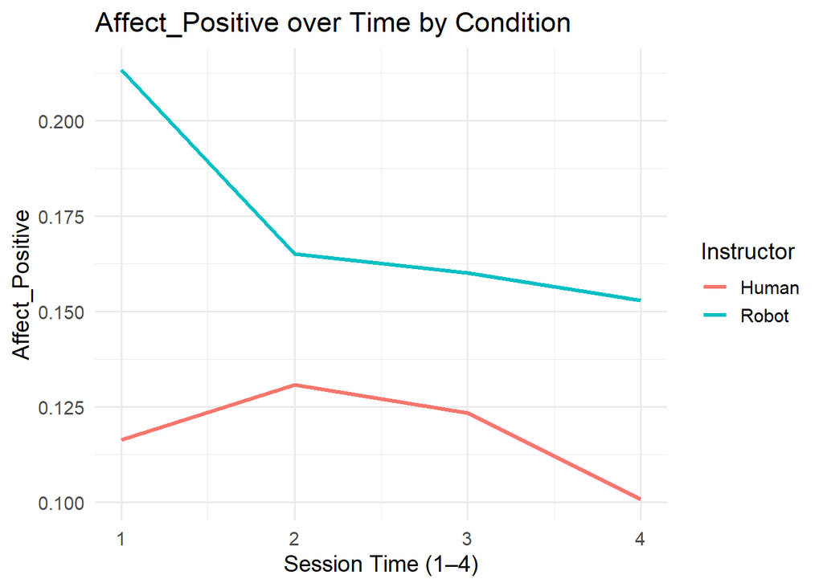

```
##
## ==============================
## Behavior: Affect_Negative
##
## Interaction Model Summary:
## # A tibble: 6 × 6
##   term                  estimate std.error statistic p.value stars
##   <chr>                    <dbl>     <dbl>     <dbl>   <dbl> <chr>
## 1 (Intercept)            -6.30       3.73   -1.69     0.0918 "."
## 2 ConditionRobot          0.0218     5.41    0.00403  0.997  ""
## 3 time_c                 -0.120      0.183  -0.658    0.510  ""
## 4 VBMAPP                  0.930      2.30    0.404    0.686  ""
## 5 ConditionRobot:time_c   0.175      0.251   0.699    0.485  ""
## 6 ConditionRobot:VBMAPP   0.110      3.36    0.0329   0.974  ""
```

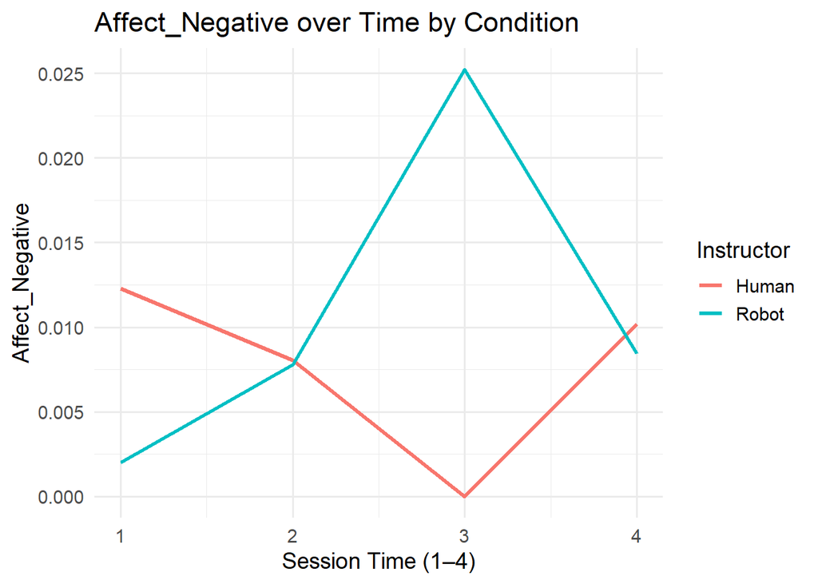

```
##
## ==============================
## Behavior: Communication_with_Instructor
##
## Interaction Model Summary:
## # A tibble: 6 × 6
##   term                  estimate std.error statistic p.value stars
##   <chr>                    <dbl>     <dbl>     <dbl>   <dbl> <chr>
## 1 (Intercept)           -3.84       2.65     -1.45     0.147 ""
## 2 ConditionRobot        -0.254      2.54     -0.100    0.920 ""
## 3 time_c                 0.00200    0.0797    0.0251   0.980 ""
## 4 VBMAPP                 1.08       1.64      0.659    0.510 ""
## 5 ConditionRobot:time_c -0.170      0.116    -1.46     0.143 ""
## 6 ConditionRobot:VBMAPP  0.0668     1.57      0.0425   0.966 ""
```

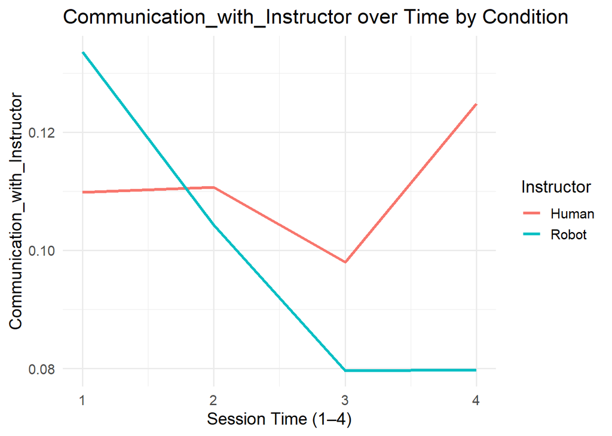

```
##
## ==============================
## Behavior: Communication_with_Instructor_Prompted
##
## Interaction Model Summary:
## # A tibble: 6 × 6
##   term                  estimate std.error statistic p.value stars
##   <chr>                    <dbl>     <dbl>     <dbl>   <dbl> <chr>
## 1 (Intercept)           -11.2        4.62     -2.43  0.0152  "*"
## 2 ConditionRobot         17.8        5.88      3.03  0.00246 "**"
## 3 time_c                 -0.0287     0.153    -0.187 0.851   ""
## 4 VBMAPP                  3.84       2.85      1.35  0.178   ""
## 5 ConditionRobot:time_c  -0.337      0.242    -1.39  0.163   ""
## 6 ConditionRobot:VBMAPP -10.9        3.66     -2.99  0.00283 "**"
```

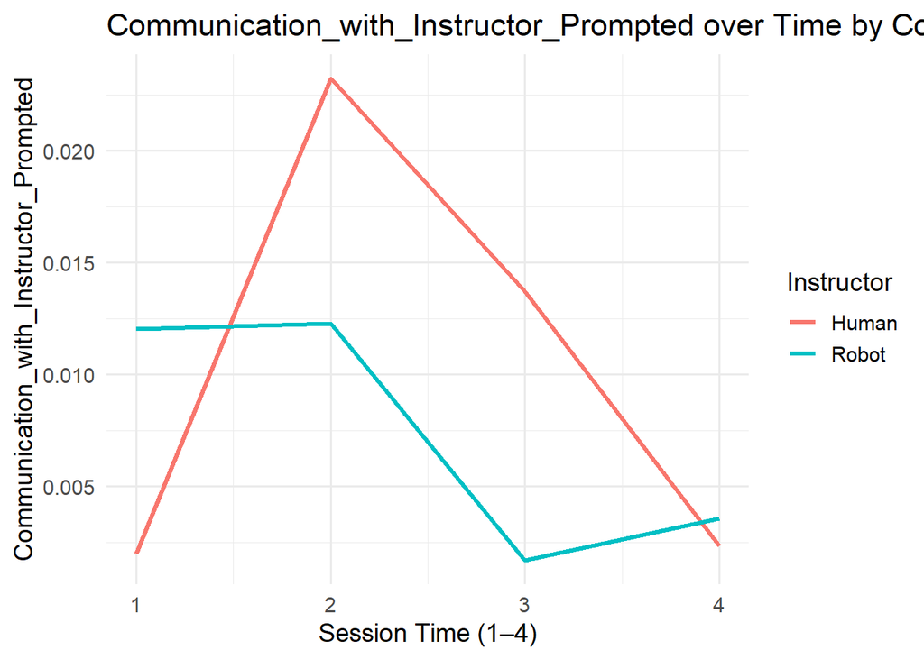

```
##
## ==============================
## Behavior: Communication_with_Therapist
##
## Interaction Model Summary:
## # A tibble: 6 × 6
##   term                  estimate std.error statistic  p.value stars
##   <chr>                    <dbl>     <dbl>     <dbl>    <dbl> <chr>
## 1 (Intercept)              5.84      2.75       2.13 0.0334   "*"
## 2 ConditionRobot          -4.87      3.85      -1.26 0.207    ""
## 3 time_c                  -0.544     0.142     -3.83 0.000126 "***"
## 4 VBMAPP                  -5.37      1.73      -3.11 0.00186  "**"
## 5 ConditionRobot:time_c    0.208     0.187      1.11 0.266    ""
## 6 ConditionRobot:VBMAPP    3.11      2.41       1.29 0.197    ""
```

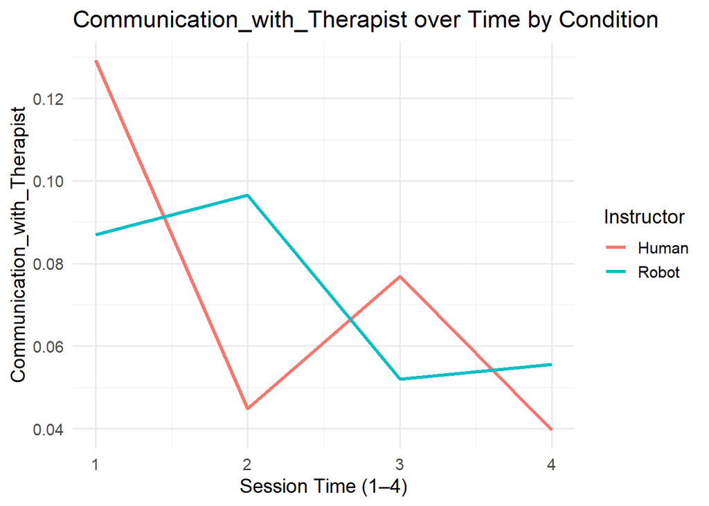

```
##
## ==============================
## Behavior: Communication_with_Indeterminent
##
## Interaction Model Summary:
## # A tibble: 6 × 6
##   term                  estimate std.error statistic p.value stars
##   <chr>                    <dbl>     <dbl>     <dbl>   <dbl> <chr>
## 1 (Intercept)             5.16       3.75      1.37   0.169  ""
## 2 ConditionRobot        -11.5        5.25     -2.19   0.0289 "*"
## 3 time_c                 -0.273      0.171    -1.59   0.111  ""
## 4 VBMAPP                 -5.71       2.36     -2.42   0.0153 "*"
## 5 ConditionRobot:time_c   0.0424     0.235     0.180  0.857  ""
## 6 ConditionRobot:VBMAPP   7.80       3.26      2.39   0.0168 "*"
```

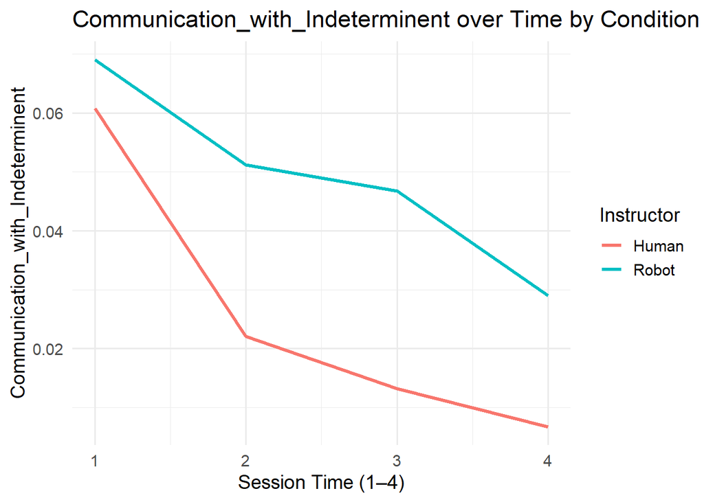

```
##
## ==============================
## Behavior: Engagement_OnTarget
##
## Interaction Model Summary:
## # A tibble: 6 × 6
##   term                  estimate std.error statistic p.value stars
##   <chr>                    <dbl>     <dbl>     <dbl>   <dbl> <chr>
## 1 (Intercept)              0.535    1.60       0.334  0.738  ""
## 2 ConditionRobot           0.812    2.28       0.356  0.722  ""
## 3 time_c                   0.172    0.0773     2.23   0.0261 "*"
## 4 VBMAPP                   0.426    0.994      0.429  0.668  ""
## 5 ConditionRobot:time_c   -0.162    0.108     -1.51   0.132  ""
## 6 ConditionRobot:VBMAPP   -0.534    1.42      -0.377  0.706  ""
```

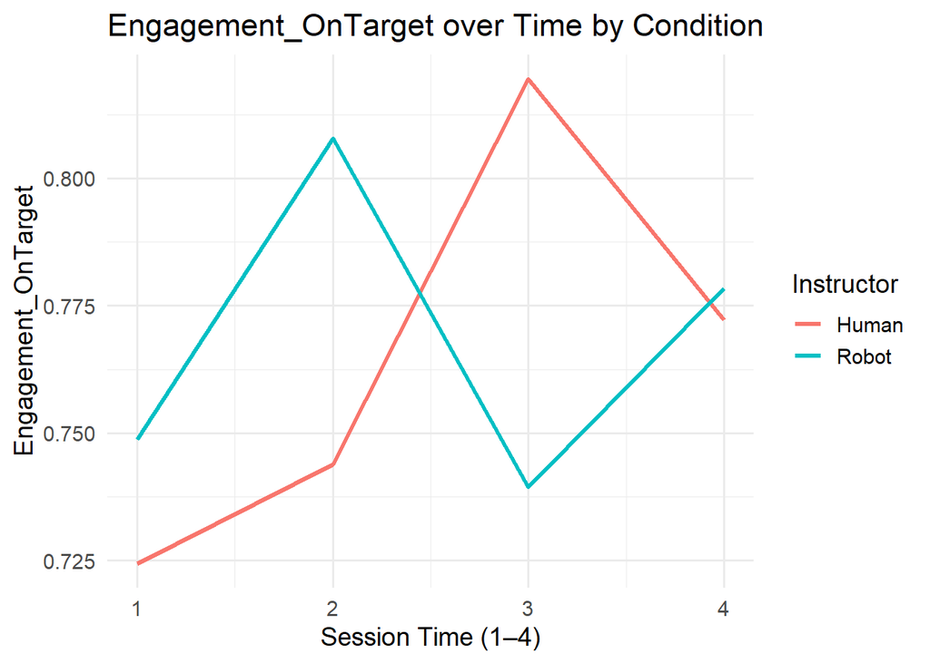

```
##
## ==============================
## Behavior: Engagement_Therapist
##
## Interaction Model Summary:
## # A tibble: 6 × 6
##   term                  estimate std.error statistic p.value stars
##   <chr>                    <dbl>     <dbl>     <dbl>   <dbl> <chr>
## 1 (Intercept)           -0.454      1.82     -0.249    0.803 ""
## 2 ConditionRobot        -0.211      2.61     -0.0807   0.936 ""
## 3 time_c                -0.00490    0.0876   -0.0559   0.955 ""
## 4 VBMAPP                -1.50       1.14     -1.32     0.186 ""
## 5 ConditionRobot:time_c -0.0219     0.123    -0.178    0.858 ""
## 6 ConditionRobot:VBMAPP  0.137      1.63      0.0840   0.933 ""
```

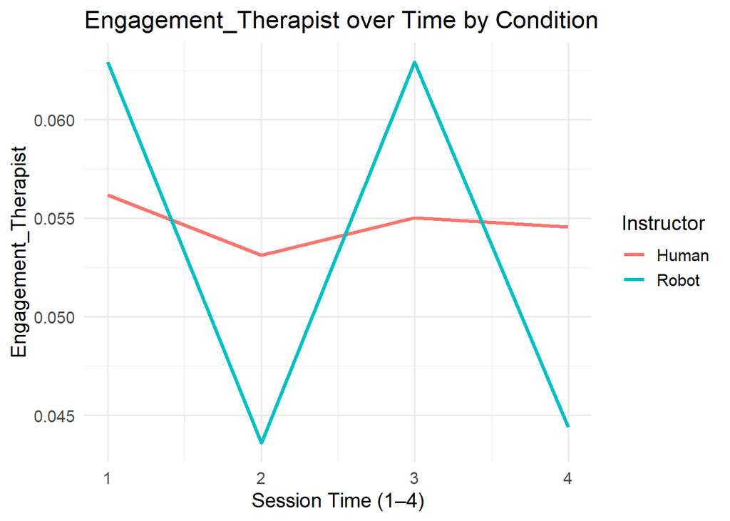

```
##
## ==============================
## Behavior: Engagement_OffTarget
##
## Interaction Model Summary:
## # A tibble: 6 × 6
##   term                  estimate std.error statistic p.value stars
##   <chr>                    <dbl>     <dbl>     <dbl>   <dbl> <chr>
## 1 (Intercept)            -1.89      1.89     -1.00   0.315   ""
## 2 ConditionRobot         -0.601     2.66     -0.226  0.821   ""
## 3 time_c                 -0.269     0.0925   -2.91   0.00362 "**"
## 4 VBMAPP                  0.0847    1.17      0.0724 0.942   ""
## 5 ConditionRobot:time_c   0.284     0.127     2.24   0.0250  "*"
## 6 ConditionRobot:VBMAPP   0.461     1.65      0.280  0.779   ""
```

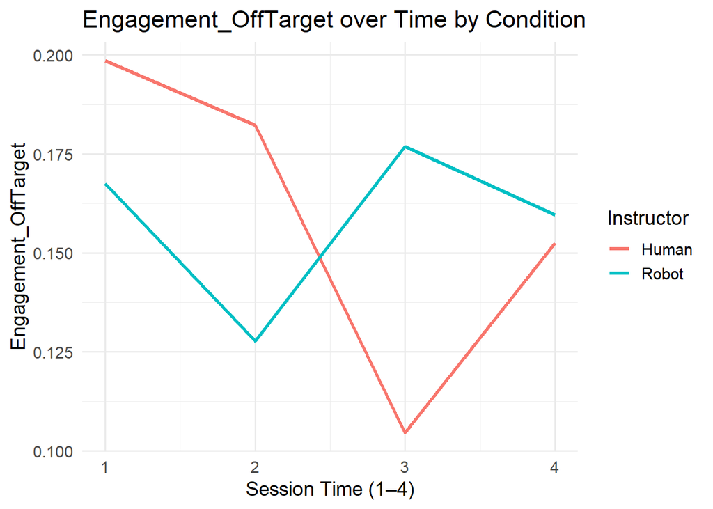

```
##
## ==============================
## Behavior: Performance_Positive
##
## Interaction Model Summary:
## # A tibble: 6 × 6
##   term                  estimate std.error statistic p.value stars
##   <chr>                    <dbl>     <dbl>     <dbl>   <dbl> <chr>
## 1 (Intercept)           -11.9        4.16     -2.87  0.00414 "**"
## 2 ConditionRobot         -1.34       2.77     -0.482 0.630   ""
## 3 time_c                  0.0276     0.106     0.261 0.794   ""
## 4 VBMAPP                  8.35       2.59      3.22  0.00126 "**"
## 5 ConditionRobot:time_c   0.0190     0.144     0.132 0.895   ""
## 6 ConditionRobot:VBMAPP   0.606      1.74      0.348 0.728   ""
```

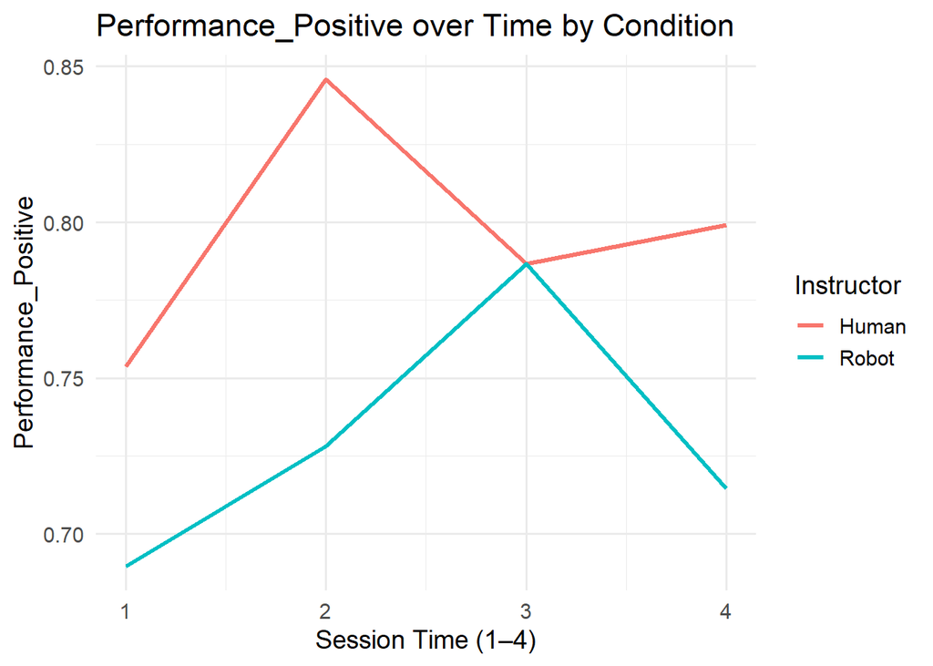

```r
library(ggplot2)
library(broom.mixed)  # for tidy output with p-values

# Load and preprocess data
df <- read.csv("~/GitHub/Circle-Time-Data-Analyses/CircleTimeData-VBMAPP.csv")
df$Condition <- factor(df$Condition, levels = c(1, 2), labels = c("Human", "Robot"))
df$time_c <- scale(df$time, center = TRUE, scale = FALSE)

vars <- c(
  "Affect_Positive", "Affect_Negative",
  "Communication_with_Instructor", "Communication_with_Instructor_Prompted",
  "Communication_with_Therapist", "Communication_with_Indeterminent",
  "Engagement_OnTarget", "Engagement_Therapist", "Engagement_OffTarget",
  "Performance_Positive"
)

# Apply beta transformation
epsilon <- 0.0001
for (v in vars) {
  df[[v]] <- (df[[v]] * (nrow(df) - 1) + epsilon) / nrow(df)
}

# Significance stars function
sig_stars <- function(p) {
  if (is.na(p)) return("")
  if (p < 0.001) return("***")
  else if (p < 0.01) return("**")
  else if (p < 0.05) return("*")
  else if (p < 0.1) return(".")
  else return("")
}

# Loop through all behaviors
for (var in vars) {
  cat("\n==============================\n")
  cat("Behavior:", var, "\n")

  # Additive model
#  form_add <- as.formula(paste0(var, " ~ Condition + time_c + VBMAPP + (1 | Subject)"))
# model1 <- glmmTMB(form_add, data = df, family = beta_family())

  # Interaction model
  form_int <- as.formula(paste0(var, " ~ Condition * time_c + Condition * VBMAPP + (1 | Subject)"))
  model2 <- glmmTMB(form_int, data = df, family = beta_family())

  # Tidy output with significance
  table <- broom.mixed::tidy(model2, effects = "fixed")
  table$stars <- sapply(table$p.value, sig_stars)

  cat("\nInteraction Model Summary:\n")
  print(table[, c("term", "estimate", "std.error", "statistic", "p.value", "stars")])

  # Plot
  p <- ggplot(df, aes(x = time, y = df[[var]], color = Condition, group = Condition)) +
    stat_summary(fun = mean, geom = "line", size = 1.2) +
    stat_summary(fun.data = mean_cl_boot, geom = "errorbar", width = 0.2) +
    labs(title = paste0(var, " over Time by Condition"),
         x = "Session Time (1–4)", y = var, color = "Instructor") +
    theme_minimal(base_size = 14)
  print(p)
}
```

## How each learning behavior predicts performance under the robot condition only?

```r
library(glmmTMB)
library(broom.mixed)

# Filter for robot condition only
df_robot <- subset(df, Condition == "Robot")

# Define outcome and predictors
predictors <- c(
  "Affect_Positive", "Affect_Negative",
  "Communication_with_Instructor", "Communication_with_Instructor_Prompted",
  "Communication_with_Therapist", "Communication_with_Indeterminent",
  "Engagement_OnTarget", "Engagement_Therapist", "Engagement_OffTarget"
)

formula_str <- paste(
  "Performance_Positive ~",
  paste(c(predictors, "VBMAPP", "time_c"), collapse = " + "),
  "+ (1 | Subject)"
)
model_robot_perf <- glmmTMB(as.formula(formula_str), data = df_robot, family = beta_family())
# Tidy output with significance stars
sig_stars <- function(p) {
  if (is.na(p)) return("")
  if (p < 0.001) return("***")
  else if (p < 0.01) return("**")
  else if (p < 0.05) return("*")
  else if (p < 0.1) return(".")
  else return("")
}
result_table <- broom.mixed::tidy(model_robot_perf, effects = "fixed")
result_table$stars <- sapply(result_table$p.value, sig_stars)

# Show the table
print(result_table[, c("term", "estimate", "std.error", "statistic", "p.value", "stars")])
```

```
## # A tibble: 12 × 6
##    term                               estimate std.error statistic p.value stars
##    <chr>                                 <dbl>     <dbl>     <dbl>   <dbl> <chr>
##  1 (Intercept)                        -70.9          NaN       NaN     NaN ""
##  2 Affect_Positive                     -1.33         NaN       NaN     NaN ""
##  3 Affect_Negative                     -2.56         NaN       NaN     NaN ""
##  4 Communication_with_Instructor       -7.46         NaN       NaN     NaN ""
##  5 Communication_with_Instructor_Pro…  21.8          NaN       NaN     NaN ""
##  6 Communication_with_Therapist        -2.89         NaN       NaN     NaN ""
##  7 Communication_with_Indeterminent     6.15         NaN       NaN     NaN ""
##  8 Engagement_OnTarget                 56.7          NaN       NaN     NaN ""
##  9 Engagement_Therapist                59.2          NaN       NaN     NaN ""
## 10 Engagement_OffTarget                53.0          NaN       NaN     NaN ""
## 11 VBMAPP                              11.0          NaN       NaN     NaN ""
## 12 time_c                              -0.0223       NaN       NaN     NaN ""
```

## How each learning behavior changes over time under the robot condition only?

```r
library(glmmTMB)
library(ggplot2)
library(broom.mixed)

# Filter for robot condition
df_robot <- subset(df, Condition == "Robot")

# Learning behavior variables
behaviors <- c(
  "Affect_Positive", "Affect_Negative",
  "Communication_with_Instructor", "Communication_with_Instructor_Prompted",
  "Communication_with_Therapist", "Communication_with_Indeterminent",
  "Engagement_OnTarget", "Engagement_Therapist", "Engagement_OffTarget", "Performance_Positive"
)

# Store results
longitudinal_results <- list()

for (behavior in behaviors) {
  formula_str <- paste0(behavior, " ~ time_c + VBMAPP + (1 | Subject)")
  model <- glmmTMB(as.formula(formula_str), data = df_robot, family = beta_family())
  tidy_model <- tidy(model, effects = "fixed")
  tidy_model$Behavior <- behavior
  longitudinal_results[[behavior]] <- tidy_model
}

# Combine all results
library(dplyr)
all_longitudinal <- bind_rows(longitudinal_results)

# Filter for time_c effect only
time_effects <- all_longitudinal %>%
  filter(term == "time_c") %>%
  mutate(
    sig = case_when(
      p.value < 0.001 ~ "***",
      p.value < 0.01 ~ "**",
      p.value < 0.05 ~ "*",
      p.value < 0.1 ~ ".",
      TRUE ~ ""
    )
  ) %>%
  arrange(p.value)

# Print summary of time effects
print(time_effects[, c("Behavior", "estimate", "std.error", "statistic", "p.value", "sig")])
```

```
## # A tibble: 10 × 6
##    Behavior                           estimate std.error statistic p.value sig
##    <chr>                                 <dbl>     <dbl>     <dbl>   <dbl> <chr>
##  1 Communication_with_Instructor_Pro…  -0.421     0.185     -2.28   0.0225 "*"
##  2 Communication_with_Therapist        -0.323     0.144     -2.25   0.0247 "*"
##  3 Communication_with_Instructor       -0.187     0.0882    -2.13   0.0335 "*"
##  4 Affect_Positive                     -0.128     0.0780    -1.64   0.101  ""
##  5 Communication_with_Indeterminent    -0.250     0.157     -1.59   0.112  ""
##  6 Engagement_Therapist                -0.0273    0.0809    -0.338  0.735  ""
##  7 Performance_Positive                 0.0386    0.115      0.337  0.736  ""
##  8 Affect_Negative                      0.0546    0.172      0.317  0.751  ""
##  9 Engagement_OffTarget                 0.0154    0.0499     0.309  0.757  ""
## 10 Engagement_OnTarget                  0.0101    0.0500     0.201  0.840  ""
```